# Iteration, Functions & Strings

Iteration

**Repeat the *same* operation multiple times**

Why not just use loops?

R is a functional programming language!

This makes it possible to wrap up loops into a function and call that function instead!

[figure not shown]

The `map()` family

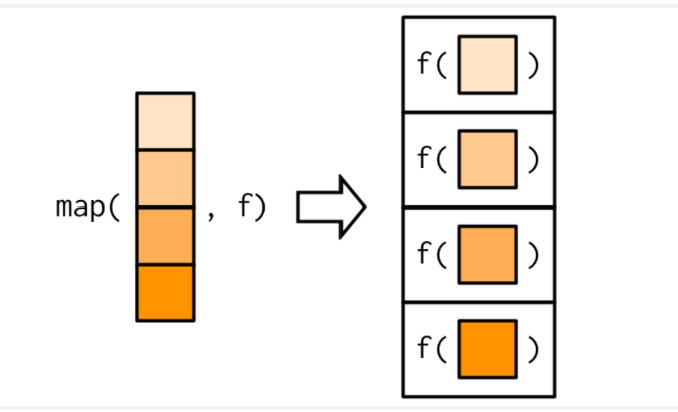

```r
simple_map <- function(x, f, ...) {
  out <- vector(mode = "list", length = length(x))
  for (i in seq_along(x)) {
    out[[i]] <- f(x[[i]], ...)
  }
  out
}
```

Summary Statistics

**Familiar**

```r
penguins %>%
  summarize(
    across(
      .cols = where(is.numeric),
      .fns = ~mean(.x, na.rm = TRUE)
      )
    )
```

What type of output does this produce?

**New**

```r
penguins %>%
  select(where(is.numeric)) %>%
  map_dbl(.f = ~mean(.x, na.rm = TRUE)
          )
```

What type of output does this produce?

What is `map_dbl()` doing?

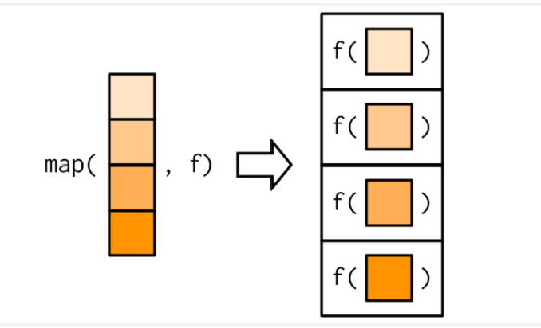

**What length of output can `f()` produce?**

Data Wrangling

**Familiar**

```r
penguins %>%
  mutate(
    across(
      .cols = where(is.numeric),
      .fns = ~scale(.x)
    )
  )
```

What type of output does this produce?

**New**

```r
penguins %>%
  map_if(is.numeric, scale)
```

What type of output does this produce?

So why use `map()` and not just use `across()`?

Not all functions are vectorized!

Today’s Lab

**Making a Song!**

A (Boring) Example

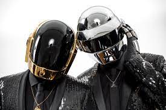

[*Around the World*](https://www.youtube.com/watch?v=K0HSD_i2DvA)

Repeats “Around the World” for the duration of the song (144 times)

A Boring `map()`

```r
around_the_world <- function(n){
  lyrics <- map_chr(.x = 1:n,
                    .f = ~ "Around the World")

  return(
    glue::glue("{lyrics}")
    )
}
```

Let’s Break it Apart

```r
map_chr(.x = 1:n,
        .f = ~ "Around the World")
```

A Handy Friend

**glue** – “interprets string literals that are small, fast, and dependency-free”

- glue does this by embedding `R` expressions in curly braces which are then evaluated and inserted into the argument string.

[figure not shown]

```r
name <- "Fred"
glue('My name is {name}.')
```

```
My name is Fred.
```

Around the World

```r
around_the_world <- function(n){
  lyrics <- map_chr(.x = 1:n,
                    .f = ~ "Around the World")

  return(glue::glue("{lyrics}") )
}
```

- Long strings are broken by line and concatenated together.

```r
around_the_world(4)
```

```
Around the World
Around the World
Around the World
Around the World
```

A Better Example

**99 Bottles of Beer**

99 bottles of beer on the wall, 99 bottles of beer. Take one down, pass it around, 98 bottles of beer on the wall…

Step One: Making Lyrics

```r
bottles_lyrics <- function(n){
  lyrics <- glue::glue("{n} bottles of beer on the wall, {n} bottles of beer \nTake one down, pass it around, {n - 1} bottles of beer on the wall")

  return(lyrics)
}

bottles_lyrics(3)
```

```
3 bottles of beer on the wall, 3 bottles of beer
Take one down, pass it around, 2 bottles of beer on the wall
```

Step Two: Making a Song

```r
bottles_song <- function(n){
  song <- map_chr(.x = n:0,
                  .f = bottles_lyrics)
  return(
    glue::glue("{song}")
  )
}
```

**Tip**

Notice how I called the `bottles_lyrics()` function inside the `bottles_song()` function – that’s exactly what a “helper” function is!

What we wanted?

```r
bottles_song(3)
```

```
3 bottles of beer on the wall, 3 bottles of beer
Take one down, pass it around, 2 bottles of beer on the wall
2 bottles of beer on the wall, 2 bottles of beer
Take one down, pass it around, 1 bottles of beer on the wall
1 bottles of beer on the wall, 1 bottles of beer
Take one down, pass it around, 0 bottles of beer on the wall
0 bottles of beer on the wall, 0 bottles of beer
Take one down, pass it around, -1 bottles of beer on the wall
```

But what about the end?

**No more bottles of beer on the wall, no more bottles of beer. Go to the store and buy some more, 99 bottles of beer on the wall…**

An Alternate Ending

```r
bottles_lyrics <- function(n){

  if(n == 0){
    lyrics <- glue::glue("No more bottles of beer on the wall, no more bottles of beer. \nGo to the store and buy some more, 99 bottles of beer on the wall")
  } else{
  lyrics <- glue::glue("{n} bottles of beer on the wall, {n} bottles of beer \nTake one down, pass it around, {n -1} bottles of beer on the wall")
  }

  return(lyrics)
}
```

A Song!

```r
bottles_song(4)
```

```
4 bottles of beer on the wall, 4 bottles of beer
Take one down, pass it around, 3 bottles of beer on the wall
3 bottles of beer on the wall, 3 bottles of beer
Take one down, pass it around, 2 bottles of beer on the wall
2 bottles of beer on the wall, 2 bottles of beer
Take one down, pass it around, 1 bottles of beer on the wall
1 bottles of beer on the wall, 1 bottles of beer
Take one down, pass it around, 0 bottles of beer on the wall
No more bottles of beer on the wall, no more bottles of beer.
Go to the store and buy some more, 99 bottles of beer on the wall
```

Your task…

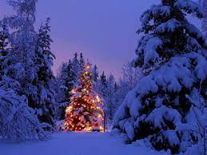

*Practice Activity 8*

- **Step One**: write a `pluralize_gift()` function
- **Step Two**: write a `make_phrase()` function
- **Step Three**: use the `make_phrase()` to generate a set of song phrases

*Lab 8* – build on these steps to generate the song lyrics

[figure not shown]